# Introducción a R Markdown

Pablo Aguirre Hörmann

6/7/2020

# R Markdown

Este es un archivo de tipo *R Markdown* (`.Rmd`), en este tipo de archivos podemos de manera simple intercalar texto con código.

El código se define en los “pedazos de código” (*code chunks*):

```r
# Una suma por ejemplo
2 + 2
```

```
## [1] 4
```

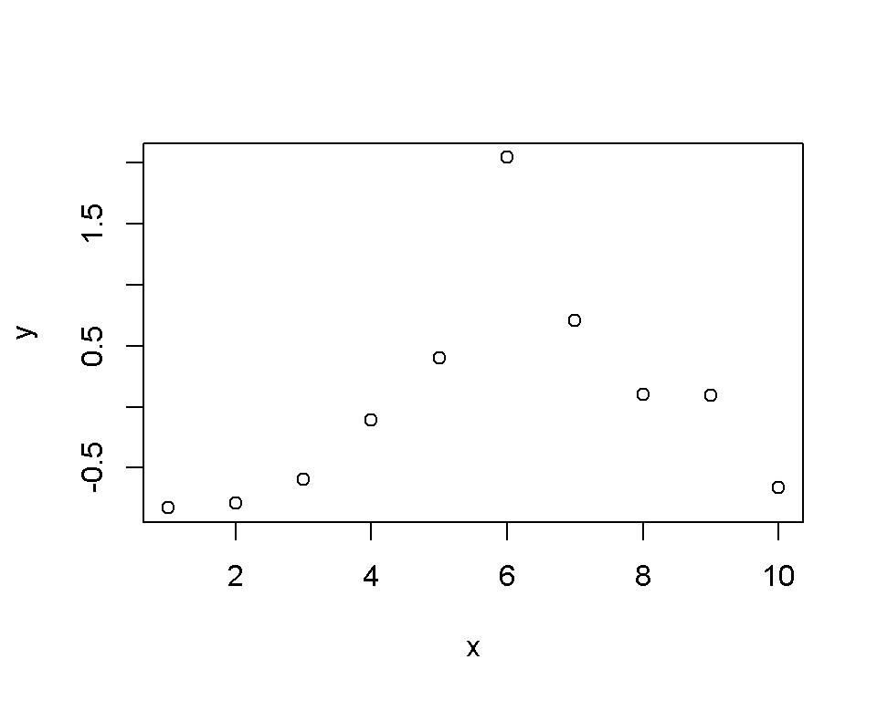

```r
# o un gráfico simple
x <- 1:10
y <- rnorm(10)
plot(x, y)
```

Y estos “pedazos de código” tienen distintas opciones que por ejemplos nos permiten solo motrar el resultado y no el código que lo genera (`echo = FALSE`):

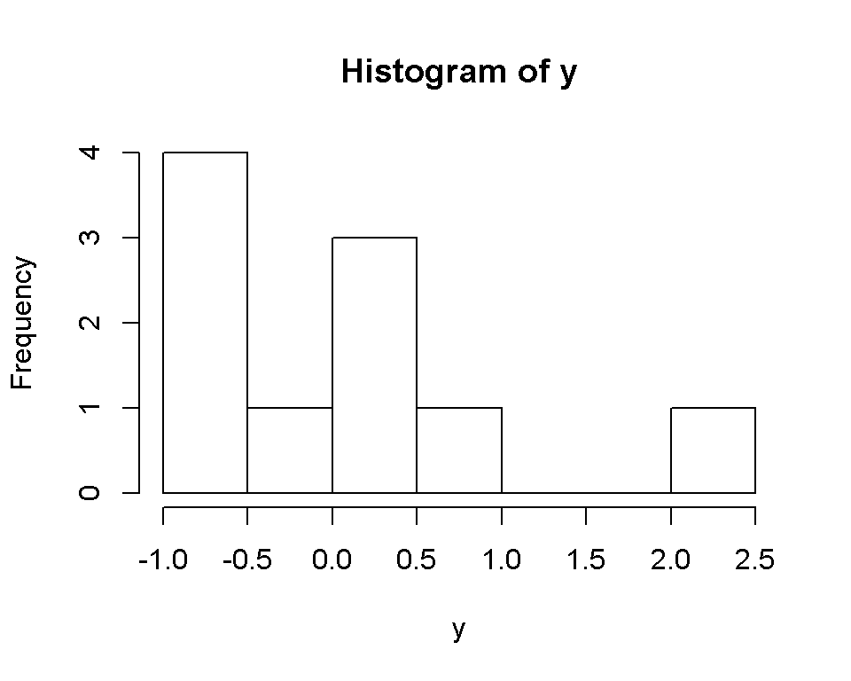

# Formato de texto

Así como hay formas de manipular el código que trabajemos existe también una gran variedad de opciones para dar formato al texto que queramos incluir en un documento:

- *cursiva*
- **negrita**
- *cursiva y negrita*
- tachado
- [link](https://gobierno.uai.cl/centro-investigacion/goblab-uai/)
- `Objetos de código`
- entre otras..

También podemos definir distintos niveles de jerarquía respecto a títulos y subtítulos

# Título 1 (`# Título 1`)

## Título 2 (`## Título 2`)

### Título 3 (`### Título 3`)

#### Título 4 (`#### Título 4`)

##### Título 5 (`##### Título 5`)

###### Título 6 (`###### Título 6`)

Por otro lado, este tipo de archivo también nos facilita escribir formulas/operaciones/objetos matemáticos (con sintáxis $\LaTeX$) tanto en linea con el texto ($\sum_{i=1}^n X_i$) como en su propio párrafo:

$$\int_0^{2\pi} \sin x~dx$$

$$\mathbf{X} = \left[\begin{array}
{rrr}
1 & 2 & 3 \\
4 & 5 & 6 \\
7 & 8 & 9
\end{array}\right]$$

Incluso podemos agregar imágenes directamente a nuestros documentos:

[figure not shown]

# Código en línea

Una de las principales caractéristicas que nos facilitará la creación de reportes automatizados es que no solo podemos escribir código en los “pedazos de código” (*code chunks*) sino que también podemos escribir **código en línea con el texto**.

```r
resultado <- 2 + 2
rel <- round(cor(x,y), 2)
```

La suma del cálculo hecho arriba es igual a **4** y la correlación entre `x` e `y` es **0.32**.

*Para más información sobre como trabajar con documentos en R Markdown ver [la hoja de referencia](https://www.rstudio.com/wp-content/uploads/2015/03/rmarkdown-spanish.pdf) y el libro [R Markdown: The Definitive Guide](https://bookdown.org/yihui/rmarkdown/)*

# Cargar datos a R

```r
library(readxl) # librería con funciones de carga de datos optimizadas
Resumen_UnidadFiscalizable <- read_excel("../Datos/Resumen_UnidadFiscalizable.xlsx")
head(Resumen_UnidadFiscalizable)
```

| UnidadFiscalizableId | RegionNombre | Latitud | Longitud | CategoriaEconomicaNombre |
| --- | --- | --- | --- | --- |
| 996 | Región del Libertador General Bernardo O'Higgins | -34.25937 | -70.80287 | Agroindustrias |
| 999 | Región del Libertador General Bernardo O'Higgins | -34.16400 | -70.77373 | Agroindustrias |
| 1002 | Región del Libertador General Bernardo O'Higgins | -34.06049 | -70.75728 | Agroindustrias |
| 1005 | Región del Libertador General Bernardo O'Higgins | -34.55359 | -70.96784 | Agroindustrias |
| 1008 | Región del Libertador General Bernardo O'Higgins | -34.57750 | -70.97440 | Agroindustrias |
| 1011 | Región del Libertador General Bernardo O'Higgins | -34.42362 | -70.85281 | Agroindustrias |

*Muchas de las funcionalidades que ocupes en `R` tendrán que ser cargadas desde librerías/paquetes. Estas se deben instalar una sola vez (`install.packages("NombreLibreria")`) y cargadas en cada nueva sesión de `R` (`library(NombreLibreria)`)*

Ahora bien, en muchos casos tendrán que interactuar con datos obtenidos desde motores de base de datos (por ejemplo *MS SQL Server*). En ese caso, para cargar datos, primero se debe generar una conexión con la base de datos para luego “llamar” las tablas que querramos ir usando.

Una conexión a un motor de base de datos se ve más o menos así:

```r
# Cargamos librerías para la conexión con motores de bases de datos
library(DBI)
library(odbc)

con <- dbConnect(odbc(),
                      Driver   = "SQL Server",
                      Server   = "ServidorX",
                      Database = "BBDD",
                      Trusted_Connection = "True",
                      Port     = 1433)
```

Y dos formas de cargar estos datos en `R` son:

```r
head(dbReadTable(con, "Resumen_UnidadFiscalizable"))
```

|  | UnidadFiscalizableId | RegionNombre | Latitud | Longitud | CategoriaEconomicaNombre |
| --- | --- | --- | --- | --- | --- |
| 1 | 996 | Región del Libertador General Bernardo O'Higgins | -34.25937 | -70.80287 | Agroindustrias |
| 2 | 999 | Región del Libertador General Bernardo O'Higgins | -34.16400 | -70.77373 | Agroindustrias |
| 3 | 1002 | Región del Libertador General Bernardo O'Higgins | -34.06049 | -70.75728 | Agroindustrias |
| 4 | 1005 | Región del Libertador General Bernardo O'Higgins | -34.55359 | -70.96784 | Agroindustrias |
| 5 | 1008 | Región del Libertador General Bernardo O'Higgins | -34.57750 | -70.97440 | Agroindustrias |
| 6 | 1011 | Región del Libertador General Bernardo O'Higgins | -34.42362 | -70.85281 | Agroindustrias |

```r
head(dplyr::tbl(con, "Resumen_UnidadFiscalizable"))
```

| UnidadFiscalizableId | RegionNombre | Latitud | Longitud | CategoriaEconomicaNombre |
| --- | --- | --- | --- | --- |
| 996 | Región del Libertador General Bernardo O'Higgins | -34.25937 | -70.80287 | Agroindustrias |
| 999 | Región del Libertador General Bernardo O'Higgins | -34.16400 | -70.77373 | Agroindustrias |
| 1002 | Región del Libertador General Bernardo O'Higgins | -34.06049 | -70.75728 | Agroindustrias |
| 1005 | Región del Libertador General Bernardo O'Higgins | -34.55359 | -70.96784 | Agroindustrias |
| 1008 | Región del Libertador General Bernardo O'Higgins | -34.57750 | -70.97440 | Agroindustrias |
| 1011 | Región del Libertador General Bernardo O'Higgins | -34.42362 | -70.85281 | Agroindustrias |

*Para más información sobre el uso de bases de datos con R ver el [siguiente link](https://db.rstudio.com/)*

# Manejo de datos

Ahora bien, cuando queramos realizar reportes tendrémos que probablemente manipular la información que tenemos. Esto dependerá de cada caso y habrán distintas formas de hacerlo. Por ejemplo, a continuación tomaremos los datos recién cargados y:

1. Seleccionaremos solo algunas de las variables/columnas para trabajar (función `select()`)
2. Filtraremos (seleccionaremos filas) los datos para eliminar valores nulos respecto a dos variables (función `filter()`)
3. Agruparemos las observaciones respecto a Región y Sector económico para luego calcular en número de UFs para cada grupo (funciónes `group_by()` y `summarise()`)
4. Los pasos anteriores generarán una “planilla” de varias filas y tres columnas que luego será modificada a un formato “más cuadrado” (función `spread()`)

*Todos estos pasos son distintas operaciones que serán unidas a través de un operador llamado “la pipa” (`%>%`) que permite escribir código con acciones de izquierda a derecha.*

```r
library(dplyr) # librería de manejo de datos (seleccionar, filtrar, agrupar, etc)
library(tidyr) # librería para modificación de "forma" de datos ("pivot", "unpivot")

# Generamos un nuevo data set "Resumen_UnidadFiscalizable_cuadro" luego de hacer toda la manipulación

Resumen_UnidadFiscalizable_cuadro <-
  # datos originales
  Resumen_UnidadFiscalizable %>%
  # seleccionamos cuatro variables/columnas
  select(UnidadFiscalizableId, RegionNombre, CategoriaEconomicaNombre) %>%
  # dejamos solo aquellas observaciones/filas que no tienen valores nulos para RegionNombre ni CategoriaEconomicaNombre
  filter(!is.na(RegionNombre) & !is.na(CategoriaEconomicaNombre)) %>%
  # Agrupamos las observaciones/filas respecto a las variables RegionNombre y CategoriaEconomicaNombre
  group_by(RegionNombre, CategoriaEconomicaNombre) %>%
  # Calculamos el número de filas/observaciones para cada uno de los grupos
  summarise("Número de UFs" = n()) %>%
  # Modificamos la forma de los datos (a "más cuadrado")
  spread(CategoriaEconomicaNombre, `Número de UFs`)

Resumen_UnidadFiscalizable_cuadro
```

| RegionNombre | Agroindustrias | Energía | Equipamiento | ETFAS | Forestal | Infraestructura de Transporte | Infraestructura Hidráulica | Infraestructura Portuaria | Instalación fabril | Minería | Monitoreo de Calidad Ambiental | Otras categorías | Pesca y Acuicultura | Saneamiento Ambiental | Transportes y almacenajes | Vivienda e Inmobiliarios |
| --- | --- | --- | --- | --- | --- | --- | --- | --- | --- | --- | --- | --- | --- | --- | --- | --- |
| Región de Antofagasta | NA | 147 | 67 | 4 | NA | 11 | 13 | 13 | 55 | 162 | 11 | 57 | 10 | 56 | 80 | 24 |
| Región de Arica y Parinacota | 4 | 24 | 58 | NA | NA | 11 | 3 | 1 | 4 | 23 | NA | 15 | 16 | 22 | 21 | 3 |
| Región de Atacama | 13 | 98 | 47 | 1 | NA | 7 | 2 | 5 | 11 | 157 | 5 | 22 | 42 | 37 | 22 | 16 |
| Región de Aysén del General Carlos Ibañez del Campo | 15 | 8 | 176 | NA | 1 | 7 | 1 | 7 | 3 | 11 | 4 | 54 | 1142 | 37 | 5 | 2 |
| Región de Coquimbo | 40 | 59 | 80 | 3 | NA | 12 | 19 | 2 | 16 | 79 | 2 | 34 | 50 | 34 | 22 | 61 |
| Región de la Araucanía | 39 | 51 | 226 | 1 | 19 | 31 | 15 | 1 | 26 | 30 | 3 | 43 | 78 | 97 | 7 | 163 |
| Región de los Lagos | 72 | 74 | 237 | 6 | 5 | 28 | 4 | 43 | 20 | 42 | 4 | 72 | 2010 | 107 | 12 | 39 |
| Región de Los Ríos | 31 | 32 | 105 | 1 | 13 | 3 | 3 | 7 | 16 | 27 | 1 | 35 | 54 | 50 | 2 | 20 |
| Región de Magallanes y la Antártica Chilena | 10 | 17 | 60 | NA | 1 | 12 | 7 | 14 | 9 | 191 | 1 | 32 | 212 | 21 | 4 | 4 |
| Región de Ñuble | 40 | 26 | 99 | NA | 12 | 3 | 3 | NA | 7 | 29 | NA | 24 | 4 | 62 | 5 | 30 |

[output cut: 6 more lines]

# Visualización

```r
Resumen_UnidadFiscalizable_reg <-
  # datos originales
  Resumen_UnidadFiscalizable %>%
  # seleccionamos cuatro variables/columnas
  select(UnidadFiscalizableId, RegionNombre, CategoriaEconomicaNombre) %>%
  # dejamos solo aquellas observaciones/filas que no tienen valores nulos para RegionNombre ni CategoriaEconomicaNombre
  filter(!is.na(RegionNombre) & !is.na(CategoriaEconomicaNombre)) %>%
  # Agrupamos las observaciones/filas respecto a las variables RegionNombre y CategoriaEconomicaNombre
  group_by(RegionNombre, CategoriaEconomicaNombre) %>%
  # Calculamos el número de filas/observaciones para cada uno de los grupos
  summarise("Número de UFs" = n())
```

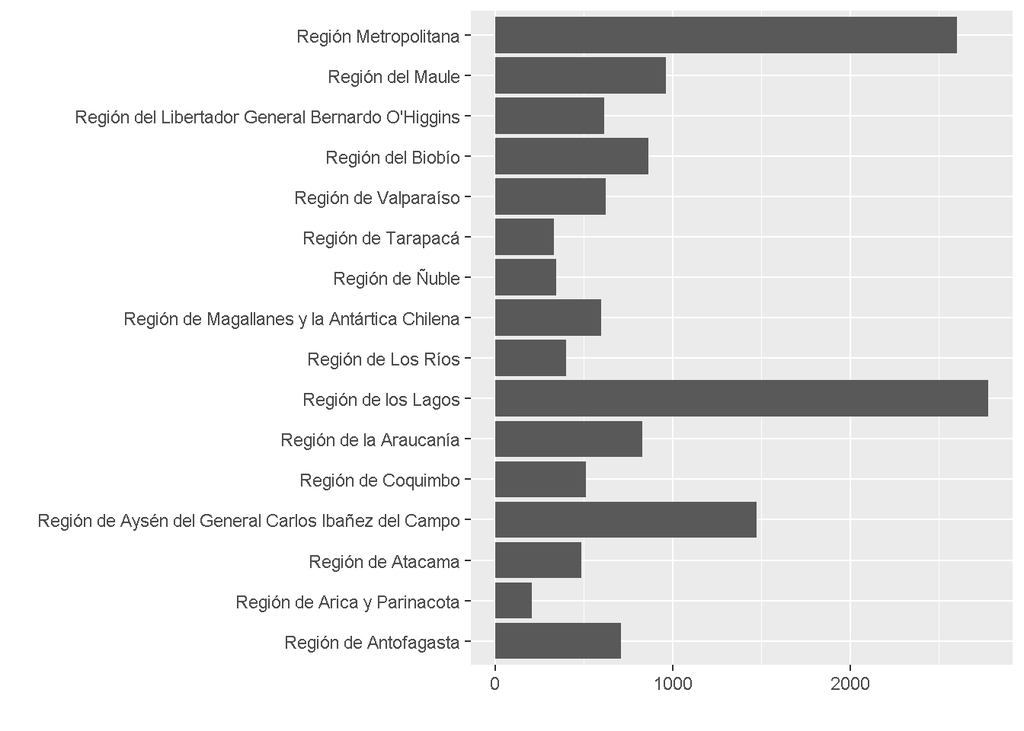

```r
library(ggplot2)

Resumen_UnidadFiscalizable_reg %>%
  ggplot(aes(RegionNombre, `Número de UFs`)) +
  geom_col() +
  coord_flip() +
  xlab("") +
  ylab("")
```

*En estos ejemplos usamos principalmente librerías del denominado `tidyverse` que es un conjunto de librerías especializadas en* data science*. Para más información pueden revisar el [siguiente link](https://www.tidyverse.org/)*